# Predecting Dimonds Price using machine learning

This nootebook looks into using various Python-based machine learning and data science labraries in an attempt to build a machine learning model capable for predicting the price of dimonds according to their attributes.

we are going to take the follwing approch:

   > Analyze diamonds by their cut, color, clarity, price, and other attributes,and predicting the price if dimonds

## 2. Data

   > The original data came from the Kaggle repository.https://www.kaggle.com/shivam2503/diamonds

## 3. Evaluation

   > If we can reach 95% accuracy at predicting the price of dimonds during the proof of concept, we 'll persue the project.

## 4. Features

   > **Creating data dictionary** Index counter

carat Carat weight of the diamond

cut Describe cut quality of the diamond. Quality in increasing order Fair, Good, Very Good, Premium, Ideal

color Color of the diamond, with D being the best and J the worst

clarity How obvious inclusions are within the diamond:(in order from best to worst, FL = flawless, I3= level 3 inclusions) FL,IF, VVS1, VVS2, VS1, VS2, SI1, SI2, I1, I2, I3

depth depth % :The height of a diamond, measured from the culet to the table, divided by its average girdle diameter

table table%: The width of the diamond's table expressed as a percentage of its average diameter

price the price of the diamond

x length mm

y width mm

# Preparing the tool

we are going to use pandas,numpy,matplotlib for data analysis and manipulation

```python
# preparing tool we neended

#Reguler EDA(exploratiry data analysis) and plotting labraries
import pandas as pd
import numpy as np
import seaborn as sns
import matplotlib.pyplot as plt
#we want our plot inside the notebook
%matplotlib inline
#Models from sklearn
from sklearn.ensemble import BaggingClassifier
from sklearn.neighbors import KNeighborsClassifier
from sklearn.linear_model import Ridge
from sklearn.linear_model import Lasso
from sklearn.linear_model import ElasticNet
from sklearn.ensemble import RandomForestClassifier
from sklearn.linear_model import LinearRegression
from sklearn.linear_model import LogisticRegression
from sklearn.ensemble import RandomForestRegressor

#Model Evaluation
from sklearn.model_selection import train_test_split
from sklearn.model_selection import cross_val_score
from sklearn.model_selection import RandomizedSearchCV,GridSearchCV
from sklearn.metrics import confusion_matrix,classification_report
from sklearn.metrics import precision_score,recall_score,f1_score
from sklearn.metrics import plot_roc_curve
```

## Load Data

```python
# loding the dataset
df = pd.read_csv("diamonds.csv")
# checking the shape of dataset
df.shape
```

```
(53940, 11)
```

## Data Exploratiry (exploratiry data analysis or EDA)

The goal here is to find out more about the data and become a subject matter export on the dataset you're working with.

1. what questions are you trying to slove?
2. what kind of data do we have and how do we treat different types?
3. what missing in the data and how we deal with it?
4. where are outlier and why you should care about them?
5. how can you add, change and remove the features to get more out of data?

```python
# seeing frist 5 records from dataset
df.head()
```

|  | Unnamed: 0 | carat | cut | color | clarity | depth | table | price | x | y | z |
| --- | --- | --- | --- | --- | --- | --- | --- | --- | --- | --- | --- |
| 0 | 1 | 0.23 | Ideal | E | SI2 | 61.5 | 55.0 | 326 | 3.95 | 3.98 | 2.43 |
| 1 | 2 | 0.21 | Premium | E | SI1 | 59.8 | 61.0 | 326 | 3.89 | 3.84 | 2.31 |
| 2 | 3 | 0.23 | Good | E | VS1 | 56.9 | 65.0 | 327 | 4.05 | 4.07 | 2.31 |
| 3 | 4 | 0.29 | Premium | I | VS2 | 62.4 | 58.0 | 334 | 4.20 | 4.23 | 2.63 |
| 4 | 5 | 0.31 | Good | J | SI2 | 63.3 | 58.0 | 335 | 4.34 | 4.35 | 2.75 |

```python
# seeing last records from dataset
df.tail()
```

|  | Unnamed: 0 | carat | cut | color | clarity | depth | table | price | x | y | z |
| --- | --- | --- | --- | --- | --- | --- | --- | --- | --- | --- | --- |
| 53935 | 53936 | 0.72 | Ideal | D | SI1 | 60.8 | 57.0 | 2757 | 5.75 | 5.76 | 3.50 |
| 53936 | 53937 | 0.72 | Good | D | SI1 | 63.1 | 55.0 | 2757 | 5.69 | 5.75 | 3.61 |
| 53937 | 53938 | 0.70 | Very Good | D | SI1 | 62.8 | 60.0 | 2757 | 5.66 | 5.68 | 3.56 |
| 53938 | 53939 | 0.86 | Premium | H | SI2 | 61.0 | 58.0 | 2757 | 6.15 | 6.12 | 3.74 |
| 53939 | 53940 | 0.75 | Ideal | D | SI2 | 62.2 | 55.0 | 2757 | 5.83 | 5.87 | 3.64 |

```python
# checking how many in each class
df["cut"].value_counts()
```

```
Ideal        21551
Premium      13791
Very Good    12082
Good          4906
Fair          1610
Name: cut, dtype: int64
```

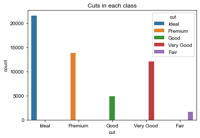

```python
# viualize how many in each class
sns.countplot(x="cut",data=df,hue="cut")
plt.title("Cuts in each class")
plt.figure(figsize=(15,15))
sns.set_style("dark")
sns.set_style("whitegrid")
```

```python
# checking the info of dataset
df.info()
```

```
<class 'pandas.core.frame.DataFrame'>
RangeIndex: 53940 entries, 0 to 53939
Data columns (total 11 columns):
 #   Column      Non-Null Count  Dtype
---  ------      --------------  -----
 0   Unnamed: 0  53940 non-null  int64
 1   carat       53940 non-null  float64
 2   cut         53940 non-null  object
 3   color       53940 non-null  object
 4   clarity     53940 non-null  object
 5   depth       53940 non-null  float64
 6   table       53940 non-null  float64
 7   price       53940 non-null  int64
 8   x           53940 non-null  float64
 9   y           53940 non-null  float64
 10  z           53940 non-null  float64
dtypes: float64(6), int64(2), object(3)
memory usage: 4.5+ MB
```

```python
# checking the null value in dataset
df.isna().sum()
```

```
Unnamed: 0    0
carat         0
cut           0
color         0
clarity       0
depth         0
table         0
price         0
x             0
y             0
z             0
dtype: int64
```

```python
# deleting unnacesary column from dataset
del df["Unnamed: 0"]
```

```python
df
```

|  | carat | cut | color | clarity | depth | table | price | x | y | z |
| --- | --- | --- | --- | --- | --- | --- | --- | --- | --- | --- |
| 0 | 0.23 | Ideal | E | SI2 | 61.5 | 55.0 | 326 | 3.95 | 3.98 | 2.43 |
| 1 | 0.21 | Premium | E | SI1 | 59.8 | 61.0 | 326 | 3.89 | 3.84 | 2.31 |
| 2 | 0.23 | Good | E | VS1 | 56.9 | 65.0 | 327 | 4.05 | 4.07 | 2.31 |
| 3 | 0.29 | Premium | I | VS2 | 62.4 | 58.0 | 334 | 4.20 | 4.23 | 2.63 |
| 4 | 0.31 | Good | J | SI2 | 63.3 | 58.0 | 335 | 4.34 | 4.35 | 2.75 |
| ... | ... | ... | ... | ... | ... | ... | ... | ... | ... | ... |
| 53935 | 0.72 | Ideal | D | SI1 | 60.8 | 57.0 | 2757 | 5.75 | 5.76 | 3.50 |
| 53936 | 0.72 | Good | D | SI1 | 63.1 | 55.0 | 2757 | 5.69 | 5.75 | 3.61 |
| 53937 | 0.70 | Very Good | D | SI1 | 62.8 | 60.0 | 2757 | 5.66 | 5.68 | 3.56 |
| 53938 | 0.86 | Premium | H | SI2 | 61.0 | 58.0 | 2757 | 6.15 | 6.12 | 3.74 |
| 53939 | 0.75 | Ideal | D | SI2 | 62.2 | 55.0 | 2757 | 5.83 | 5.87 | 3.64 |

53940 rows × 10 columns

```python
# checking the structure of data
df.describe()
```

|  | carat | depth | table | price | x | y | z |
| --- | --- | --- | --- | --- | --- | --- | --- |
| count | 53940.000000 | 53940.000000 | 53940.000000 | 53940.000000 | 53940.000000 | 53940.000000 | 53940.000000 |
| mean | 0.797940 | 61.749405 | 57.457184 | 3932.799722 | 5.731157 | 5.734526 | 3.538734 |
| std | 0.474011 | 1.432621 | 2.234491 | 3989.439738 | 1.121761 | 1.142135 | 0.705699 |
| min | 0.200000 | 43.000000 | 43.000000 | 326.000000 | 0.000000 | 0.000000 | 0.000000 |
| 25% | 0.400000 | 61.000000 | 56.000000 | 950.000000 | 4.710000 | 4.720000 | 2.910000 |
| 50% | 0.700000 | 61.800000 | 57.000000 | 2401.000000 | 5.700000 | 5.710000 | 3.530000 |
| 75% | 1.040000 | 62.500000 | 59.000000 | 5324.250000 | 6.540000 | 6.540000 | 4.040000 |
| max | 5.010000 | 79.000000 | 95.000000 | 18823.000000 | 10.740000 | 58.900000 | 31.800000 |

## DAIMONS PRICE ACCORDING TO THE CUT

```python
pd.crosstab(df.price,df.cut)
```

| cut price | Fair | Good | Ideal | Premium | Very Good |
| --- | --- | --- | --- | --- | --- |
| 326 | 0 | 0 | 1 | 1 | 0 |
| 327 | 0 | 1 | 0 | 0 | 0 |
| 334 | 0 | 0 | 0 | 1 | 0 |
| 335 | 0 | 1 | 0 | 0 | 0 |
| 336 | 0 | 0 | 0 | 0 | 2 |
| ... | ... | ... | ... | ... | ... |
| 18803 | 0 | 0 | 0 | 0 | 1 |
| 18804 | 0 | 0 | 1 | 0 | 0 |
| 18806 | 0 | 0 | 1 | 0 | 0 |
| 18818 | 0 | 0 | 0 | 0 | 1 |
| 18823 | 0 | 0 | 0 | 1 | 0 |

11602 rows × 5 columns

## Cut vs price in dataset

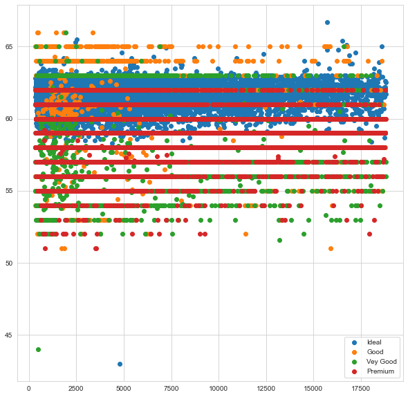

```python
# create the figure
plt.figure(figsize=(10,10))
# create the scatter plot for the ideal cut
plt.scatter(df.price[df.cut=="Ideal"],
           df.depth[df.cut=="Ideal"])
# create the scatter plot for the good cut
plt.scatter(df.price[df.cut=="Good"],
           df.table[df.cut=="Good"])
# create the scatter plot for the Very Good cut
plt.scatter(df.price[df.cut=="Very Good"],
           df.table[df.cut=="Very Good"])
# create the scatter plot for the Premium
plt.scatter(df.price[df.cut=="Premium"],
           df.table[df.cut=="Premium"])
plt.legend(["Ideal","Good","Vey Good","Premium","Fair"])
```

## dimonds color according to cut

```python
pd.crosstab(df.color,df.cut)
```

| cut color | Fair | Good | Ideal | Premium | Very Good |
| --- | --- | --- | --- | --- | --- |
| D | 163 | 662 | 2834 | 1603 | 1513 |
| E | 224 | 933 | 3903 | 2337 | 2400 |
| F | 312 | 909 | 3826 | 2331 | 2164 |
| G | 314 | 871 | 4884 | 2924 | 2299 |
| H | 303 | 702 | 3115 | 2360 | 1824 |
| I | 175 | 522 | 2093 | 1428 | 1204 |
| J | 119 | 307 | 896 | 808 | 678 |

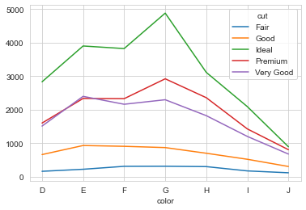

```python
# viualize the crosatb in plot
pd.crosstab(df.color,df.cut).plot()
```

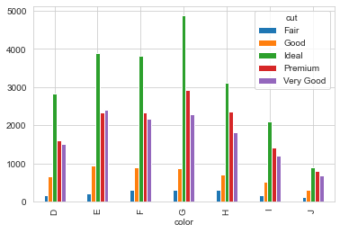

```python
# cross tab according to bar plot
pd.crosstab(df.color,df.cut).plot(kind="bar")
plt.figure(figsize=(10,10))
```

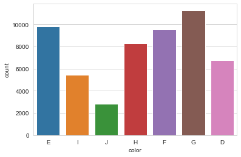

```python
# checking the distribution of color column
sns.countplot(x="color", data=df)
```

```python
df.head(1)
```

|  | carat | cut | color | clarity | depth | table | price | x | y | z |
| --- | --- | --- | --- | --- | --- | --- | --- | --- | --- | --- |
| 0 | 0.23 | Ideal | E | SI2 | 61.5 | 55.0 | 326 | 3.95 | 3.98 | 2.43 |

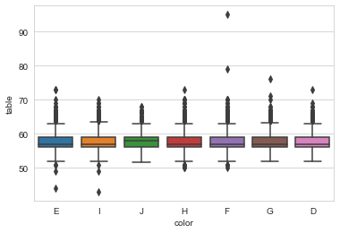

```python
#checking the distribution of table column
sns.boxplot(x="color",y="table",data=df)
```

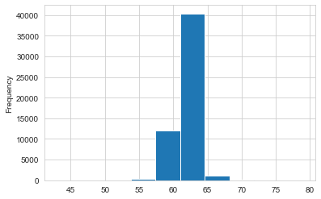

```python
# checking the contribution of depth column
df.depth.plot.hist()
```

```python
# finding the corr relation between differnt column
df.corr()
```

|  | carat | depth | table | price | x | y | z |
| --- | --- | --- | --- | --- | --- | --- | --- |
| carat | 1.000000 | 0.028224 | 0.181618 | 0.921591 | 0.975094 | 0.951722 | 0.953387 |
| depth | 0.028224 | 1.000000 | -0.295779 | -0.010647 | -0.025289 | -0.029341 | 0.094924 |
| table | 0.181618 | -0.295779 | 1.000000 | 0.127134 | 0.195344 | 0.183760 | 0.150929 |
| price | 0.921591 | -0.010647 | 0.127134 | 1.000000 | 0.884435 | 0.865421 | 0.861249 |
| x | 0.975094 | -0.025289 | 0.195344 | 0.884435 | 1.000000 | 0.974701 | 0.970772 |
| y | 0.951722 | -0.029341 | 0.183760 | 0.865421 | 0.974701 | 1.000000 | 0.952006 |
| z | 0.953387 | 0.094924 | 0.150929 | 0.861249 | 0.970772 | 0.952006 | 1.000000 |

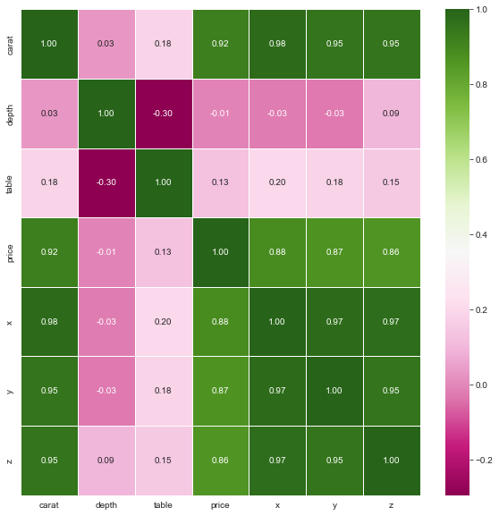

```python
# make the correlation make batter
corr_matrix = df.corr()
fig, ax = plt.subplots(figsize=(10,10))
ax = sns.heatmap(corr_matrix,
                annot=True,
                linewidth=0.5,
                 fmt=".2f",
                 cbar=True,
                 cmap="PiYG");
```

```python
 #split the data into x and y
x = df.iloc[:4000,[0,1,2,3]]
y=df.loc[:3999,"price"]
```

```python
# preprocessing of data in one hot Encoder
from sklearn.preprocessing import OneHotEncoder
from sklearn.compose import ColumnTransformer
column=["cut","color","clarity"]
one_hot=OneHotEncoder()
transform=ColumnTransformer([("one_hot",
                             one_hot,
                             column)],
                           remainder="passthrough")
transformed_x = transform.fit_transform(x)
transformed_x
```

```
<4000x21 sparse matrix of type '<class 'numpy.float64'>'
	with 16000 stored elements in Compressed Sparse Row format>
```

```python
 #split the data into train and test
x_train, x_test, y_train, y_test = train_test_split(transformed_x,
                                                    y,
                                                  test_size = 0.3)
```

Now we have got our data split into train and test set .it's time to build up the machine lerning model

we'll train it (finding the pattren) on the training set.

And we a'll test it (use the pattren) on the testing set.

- LogisticRegression
- K-nearest neighbour Classifier
- Random ForetsClassifier
- BaggingClassifier
- KNeighborsClassifier
- linear_model
- LinearRegression

```python
# put the model into the dictonary
models = {"logistic":LogisticRegression(),
         "kNN":KNeighborsClassifier(),
         "reg":RandomForestRegressor(),
         "random":RandomForestClassifier(),
         "regression":LinearRegression(),
          "ridge":Ridge(),
          "ela":ElasticNet(),
          "lasso":Lasso()
         }
# make the funcation of scores
def fit_and_score(models,x_train,x_test,y_train,y_test):
    # set random seed
    np.random.seed(42)
     # make the dictonary for the model scores
    model_scores = {}
    # make the loop for model rotation
    for name,model in models.items():
        # fit the model
        model.fit(x_train, y_train)
        # fit score
        model_scores[name] = model.score(x_test, y_test)
    return model_scores
```

```python
model_score = fit_and_score(models=models,
                           x_train=x_train,
                           y_train=y_train,
                           x_test=x_test,
                           y_test=y_test)
model_score
```

```
{'logistic': 0.06,
 'kNN': 0.10083333333333333,
 'reg': 0.9538640035882859,
 'random': 0.14416666666666667,
 'regression': 0.8946143092506467,
 'ridge': 0.8940083707253905,
 'ela': 0.09956685505215868,
 'lasso': 0.8945257235128753}
```

## Model compersion

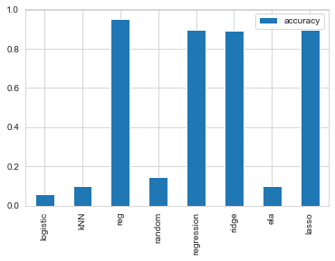

```python
model_comperison = pd.DataFrame(model_score, index=["accuracy"])
model_comperison.T.plot(kind="bar")
```

Now we got baseline model ... and we know models frist prediction are not always what we should based our next steps off.

What should we do?

let's look at the following:

- Hayperperametter tunning
- Features importance
- confusion matrix
- Cross validation
- Precesion
- Recall
- f1 score
- Classification Report
- ROC curve
- Area under the curve(AUC)

## Hapreparameter tunning of models

........ using Randomize saerach cv

```python
# create the dictonary for the RandomForestRegressor
regressor_grid={#'bootstrap': [True, False],
                'max_depth': [10, 20, 30, None],
                'max_features': ['auto', 'sqrt'],
                'min_samples_leaf': [1, 2, 4],
                'min_samples_split': [2, 5, 10],
                'n_estimators': [200, 400, 600, 800, 1000, 1200, 1400, 1600, 1800, 2000]}

# create the dictonary for the linear regression
linear_grid={'x_copy' : [True],
                 'fit_intercept' : [bool,True],
            "n_jobs":[int],
            "normalize":[bool,True]}
```

```python
# tune the RandomForestRegressor
np.random.seed(42)
# regressor setup for model
regressor_grid_scv = RandomizedSearchCV(RandomForestRegressor(),
                                        param_distributions=regressor_grid,
                                        cv=5,
                                        n_iter=20,
                                        verbose=True
                                        )
# fit the model
regressor_grid_scv.fit(x_train, y_train)
```

```
Fitting 5 folds for each of 20 candidates, totalling 100 fits
```

```
RandomizedSearchCV(cv=5, estimator=RandomForestRegressor(), n_iter=20,
                   param_distributions={'max_depth': [10, 20, 30, None],
                                        'max_features': ['auto', 'sqrt'],
                                        'min_samples_leaf': [1, 2, 4],
                                        'min_samples_split': [2, 5, 10],
                                        'n_estimators': [200, 400, 600, 800,
                                                         1000, 1200, 1400, 1600,
                                                         1800, 2000]},
                   verbose=True)
```

```python
regressor_grid_scv.best_params_
```

```
{'n_estimators': 1800,
 'min_samples_split': 10,
 'min_samples_leaf': 4,
 'max_features': 'auto',
 'max_depth': 30}
```

```python
regressor_grid_scv.score(x_test,y_test)
```

```
0.9569952386039567
```

```python
# hyperparameter tunning for the linear_regressor
regression_grid_cv = GridSearchCV(RandomForestRegressor(),
                                 cv=5,
                                 param_grid=regressor_grid,
                                 verbose=True)
# train the model
regression_grid_cv.fit(x_train,y_train)
```

```
Fitting 5 folds for each of 720 candidates, totalling 3600 fits
```